# HW 02

Author

Brooke Pacheco

```r
# load packages
library(countdown)
library(scales)
library(tidyverse)
library(janitor)
library(colorspace)
library(broom)
library(fs)
library(ggridges)
library(ggplot2)
library(dplyr)
library(here)
library(glue)
library(ggthemes)

# set theme for ggplot2
ggplot2::theme_set(ggplot2::theme_minimal(base_size = 11))

# set width of code output
options(width = 65)

# set figure parameters for knitr
knitr::opts_chunk$set(
  fig.width = 7, # 7" width
  fig.asp = 0.618, # the golden ratio
  fig.retina = 3, # dpi multiplier for displaying HTML output on retina
  fig.align = "center", # center align figures
  dpi = 300 # higher dpi, sharper image
)

# install pacman if needed
if (!require("pacman"))
  install.packages("pacman")

# use this line for installing/loading
pacman::p_load(
  tidyverse, janitor, colorspace, broom, fs,
  ggridges, ggplot2, dplyr, countdown, ggthemes, devtools
)

# install dsbox if needed
if (!require("dsbox")) devtools::install_github("databrew/dsbox")

# load dsbox package
library(dsbox)

# global ggplot theme
theme_set(theme_minimal(base_size = 11))
```

## 1 - A new day, a new plot, a new geom

[figure not shown]

```r
# load edibnb dataset into environment
data(edibnb)

# Read in data from edinbnb data and clean
write_csv(edibnb, "edibnb_data.csv")

# extract the data
edibnb <- edibnb |>
  select(neighbourhood, review_scores_rating) |>
  filter(!is.na(review_scores_rating)) |>
  filter(!is.na(neighbourhood), neighbourhood != "") |>
  group_by(neighbourhood) |>
  mutate(median_score = median(review_scores_rating)) |>
  ungroup() |>
  filter(!is.na(median_score)) |>
  mutate(neighbourhood = fct_reorder(neighbourhood, median_score))

# make the plot
ggplot(edibnb, aes(x = review_scores_rating, y = neighbourhood)) +
  geom_density_ridges(scale = 4, rel_min_height = 0.01) +
  coord_cartesian(clip = "off") +
  scale_x_continuous(limits = c(80, 103), expand = c(0, 0)) +
  labs(
    title = "Airbnb Review Scores of Edinburgh Neighborhoods",
    x = "Review Score",
    y = "Neighborhood"
  ) +
  theme_ridges()
```

The plot displays the median Airbnb review scores across Edinburgh neighborhoods. Most neighborhoods receive median scores above 90, with Haymarket having the lowest median score and Morningside the highest.

### Sources

Tools on using the write function directly used from: https://readr.tidyverse.org/reference/write_delim.html

## 2 - Foreign Connected PACs

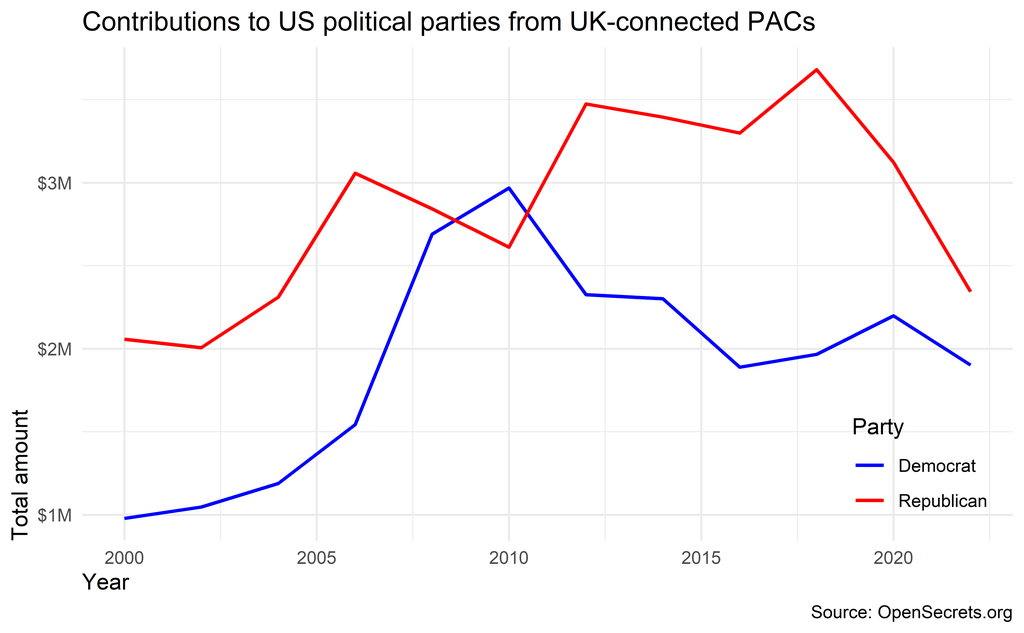

```r
# get a list of files with "Foreign Connected PAC" in their names
list_of_files <- dir_ls(path = "data", regexp = "Foreign Connected PAC")

# read all files and row bind them
# keeping track of the file name in a new column called year
pac <- read_csv(list_of_files, id = "year") |>
  janitor::clean_names() |>
  mutate(year = stringr::str_extract(year, "\\d{4}"),
         year = as.integer(year)) |>
  separate(country_of_origin_parent_company,
           into = c("country_of_origin", "parent_company"),
           sep = "/",
           fill = "right") |>
  mutate(
    dems = readr::parse_number(dems),
    repubs = readr::parse_number(repubs)
  ) |>
  select(year, pac_name_affiliate, country_of_origin, parent_company, dems, repubs) |>
  pivot_longer(
    cols = c(dems, repubs),
    names_to = "party",
    values_to = "amount"
  ) |>
  mutate(
    party = case_when(
      party == "dems" ~ "Democrat",
      party == "repubs" ~ "Republican",
      TRUE ~ party
    ))

# extract uk data
uk <- pac |>
  filter(country_of_origin %in% c("United Kingdom", "UK")) |>
  group_by(year, party) |>
  summarize(total_amount = sum(amount, na.rm = TRUE), .groups = "drop") |>
  mutate(total_amount = total_amount / 1000000) |>
  mutate(year = year + 1) |>
  arrange(year, party)

# plot - UK contributions to US political parties
ggplot(uk, aes(x = year, y = total_amount, color = party, group = party)) +
  geom_line(linewidth = 0.8) +
  scale_color_manual(
    values = c("Democrat" = "blue", "Republican" = "red")
  ) +
  labs (
    title = "Contributions to US political parties from UK-connected PACs",
    x = "Year",
    y = "Total amount",
    color = "Party",
    caption = "Source: OpenSecrets.org"
  ) +
  scale_x_continuous(breaks = seq(2000, 2020, 5)) +
  scale_y_continuous(labels = label_dollar(suffix = "M")) +
  theme_minimal(base_size = 11) +
  theme(
    legend.position = c(0.9, 0.15),
    axis.title.x = element_text(hjust = 0),
    axis.title.y = element_text(hjust = 0)
  )
```

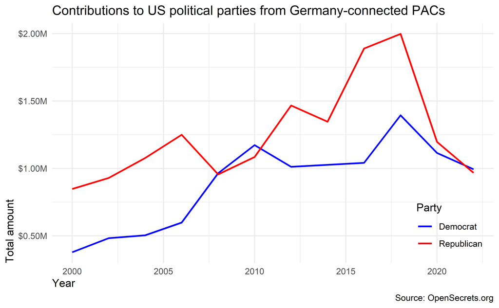

```r
# extract Germany data
germany <- pac |>
  filter(country_of_origin %in% c("Germany")) |>
  group_by(year, party) |>
  summarize(total_amount = sum(amount, na.rm = TRUE), .groups = "drop") |>
  mutate(total_amount = total_amount / 1000000) |>
  mutate(year = year + 1) |>
  arrange(year, party)

# plot - German contributions to US political parties
ggplot(germany, aes(x = year, y = total_amount, color = party, group = party)) +
  geom_line(linewidth = 0.8) +
  scale_color_manual(
    values = c("Democrat" = "blue", "Republican" = "red")
  ) +
  labs (
    title = "Contributions to US political parties from Germany-connected PACs",
    x = "Year",
    y = "Total amount",
    color = "Party",
    caption = "Source: OpenSecrets.org"
  ) +
  scale_x_continuous(breaks = seq(2000, 2020, 5)) +
  scale_y_continuous(labels = label_dollar(suffix = "M")) +
  theme_minimal(base_size = 11) +
  theme(
    legend.position = c(0.9, 0.15),
    axis.title.x = element_text(hjust = 0),
    axis.title.y = element_text(hjust = 0)
  )
```

### Sources

Usage of string extract inspired by: https://stringr.tidyverse.org/reference/str_extract.html#ref-examples

Separating character string and using fill arguement inspired by: https://tidyr.tidyverse.org/reference/separate.html

Taken parse number from to remove ‘$’ from column data: https://readr.tidyverse.org/reference/parse_number.html

Referenced cheat sheet page for readr: https://readr.tidyverse.org/

Referenced this page for pivot_longer parameters: https://tidyr.tidyverse.org/reference/pivot_longer.html

## 3 - Median housing prices in the US

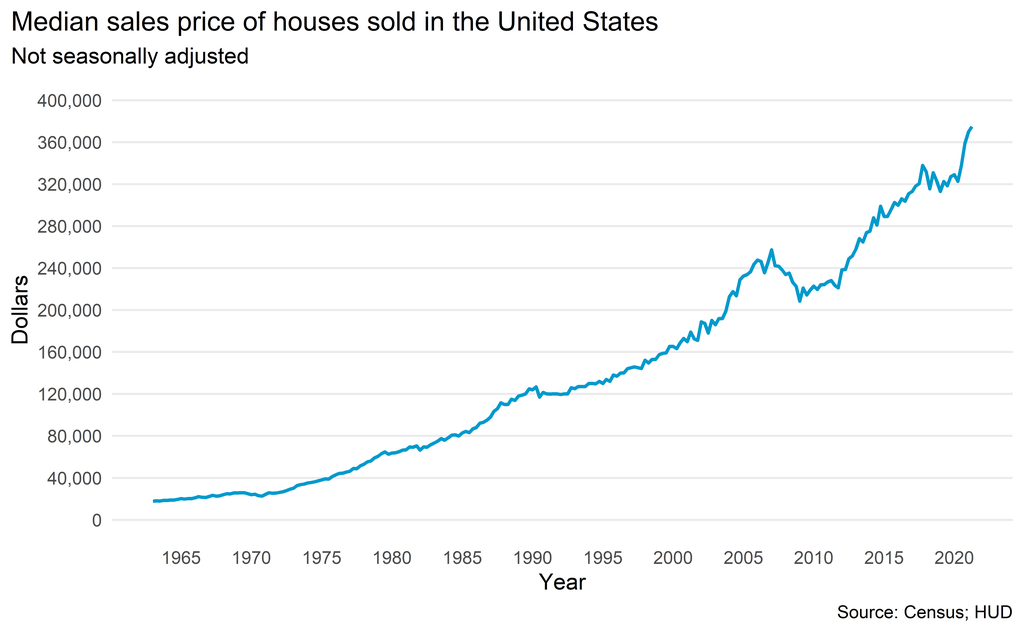

```r
# Read in data from median housing file
median_housing <- read_csv(here("data", "median-housing.csv")) |>
  mutate(
    date = DATE,
    price = MSPUS
  ) |>
  select(date, price)

# Read in data from recessions file
recessions <- read_csv(here("data" ,"recessions.csv"))

# create the plot
ggplot(median_housing, aes(x = date, y = price)) +
  geom_line(linewidth = 0.8, color = "deepskyblue3") +
  scale_x_date(
    breaks = seq(as.Date("1965-01-01"), as.Date("2020-01-01"), by = "5 years"),
    date_labels = "%Y"
  ) +
  scale_y_continuous(
    breaks = seq(0, 400000, 40000),
    labels = comma,
    limits = c(0, 400000)) +
  labs (
    x = "Year",
    y = "Dollars",
    title = "Median sales price of houses sold in the United States",
    subtitle = "Not seasonally adjusted",
    caption = "Source: Census; HUD"
  ) +
  theme(
    plot.title.position = "plot",
    panel.grid.minor.x = element_blank(),
    panel.grid.major.x = element_blank(),
    panel.grid.minor.y = element_blank()
  )
```

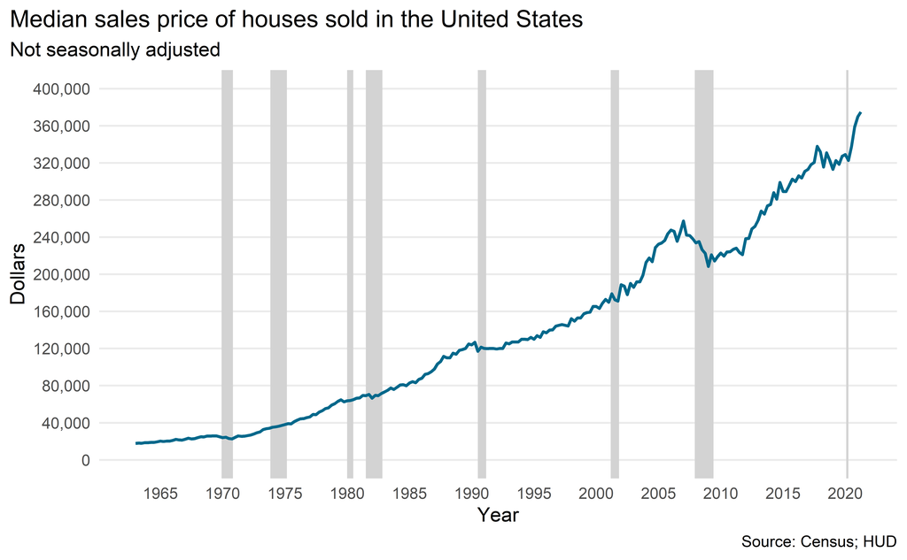

```r
# identify recessions
recessions <- recessions |>
  mutate(
    timeframe = case_when(
      (Peak >= min(median_housing$date) & Peak <= max(median_housing$date)) |
      (Trough >= min(median_housing$date) & Trough <= max(median_housing$date)) ~ TRUE,
      TRUE ~ FALSE
    )
  ) |>
  filter(
    Peak <= max(median_housing$date) & Trough >= min(median_housing$date)
  )

# create the second plot - adding recession data
ggplot(median_housing, aes(x = date, y = price)) +
  geom_rect(
    data = recessions,
    aes(xmin = Peak, xmax = Trough, ymin = -Inf, ymax = Inf),
    fill = "lightgray", inherit.aes = FALSE
  ) +
  geom_line(linewidth = 0.8, color = "deepskyblue4") +
  scale_x_date(
    breaks = seq(as.Date("1965-01-01"), as.Date("2020-01-01"), by = "5 years"),
    date_labels = "%Y"
  ) +
  scale_y_continuous(
    breaks = seq(0, 400000, 40000),
    labels = comma,
    limits = c(0, 400000)) +
  labs (
    x = "Year",
    y = "Dollars",
    title = "Median sales price of houses sold in the United States",
    subtitle = "Not seasonally adjusted",
    caption = "Source: Census; HUD"
  ) +
  theme(
    plot.title.position = "plot",
    panel.grid.minor.x = element_blank(),
    panel.grid.major.x = element_blank(),
    panel.grid.minor.y = element_blank()
  )
```

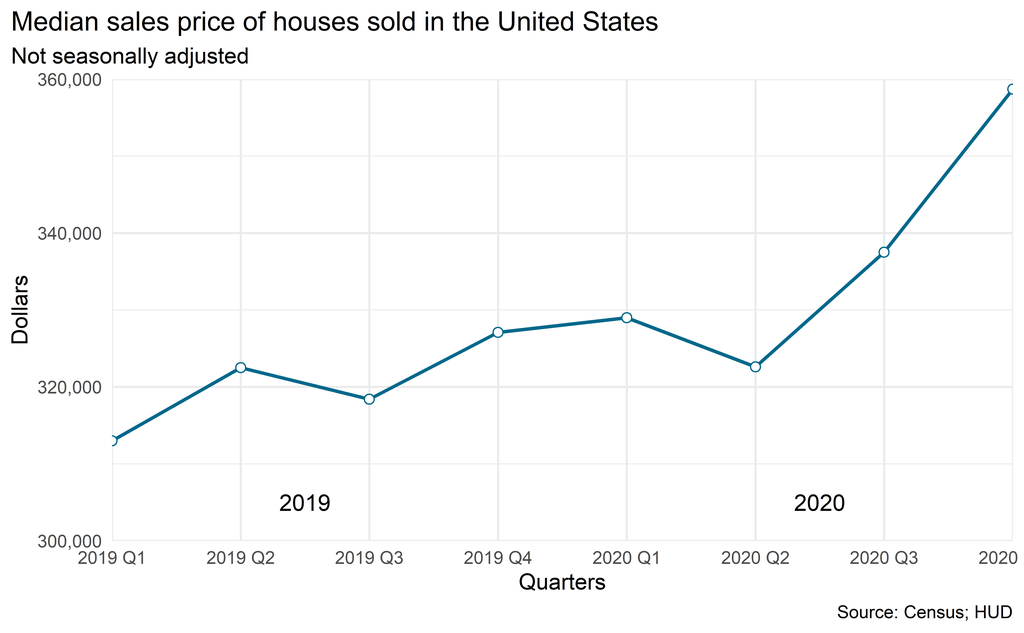

```r
# add year and quarter columns
median_housing_subset <- median_housing |>
  mutate(
    year = year(date),
    quarter = case_when(
      date >= as.Date("2019-01-01") & date <= as.Date("2019-03-31") ~ "Q1",
      date >= as.Date("2019-04-01") & date <= as.Date("2019-06-30") ~ "Q2",
      date >= as.Date("2019-07-01") & date <= as.Date("2019-09-30") ~ "Q3",
      date >= as.Date("2019-10-01") & date <= as.Date("2019-12-31") ~ "Q4",
      date >= as.Date("2020-01-01") & date <= as.Date("2020-03-31") ~ "Q1",
      date >= as.Date("2020-04-01") & date <= as.Date("2020-06-30") ~ "Q2",
      date >= as.Date("2020-07-01") & date <= as.Date("2020-09-30") ~ "Q3",
      date >= as.Date("2020-10-01") & date <= as.Date("2020-12-31") ~ "Q4",
      TRUE ~ ""
    ),
    year_quarter = paste(year, quarter),
    year_quarter = factor(
      year_quarter,
      levels = c("2019 Q1", "2019 Q2", "2019 Q3", "2019 Q4","2020 Q1", "2020 Q2", "2020 Q3", "2020 Q4"
      )
    )
  ) |>
  filter(year %in% c("2019", "2020"))

# create the third plot - with year subset and quarter
ggplot(median_housing_subset, aes(x = year_quarter, y = price, group = 1)) +
  geom_line(linewidth = 0.8, color = "deepskyblue4") +
  scale_y_continuous(
    breaks = seq(300000, 360000, 20000),
    labels = comma,
    expand = c(0, 0)
  ) +
  scale_x_discrete(
  limits = c("2019 Q1", "2019 Q2", "2019 Q3", "2019 Q4", "2020 Q1", "2020 Q2", "2020 Q3", "2020 Q4"),
  expand = c(0, 0)
  ) +
  geom_point(shape = 21, fill = "white", size = 2, color = "deepskyblue4", show.legend = FALSE) +
  labs (
    x = "Quarters",
    y = "Dollars",
    title = "Median sales price of houses sold in the United States",
    subtitle = "Not seasonally adjusted",
    caption = "Source: Census; HUD"
  ) +
  annotate(
    geom = "text",
    x = c(2.5, 6.5),
    y = 305000,
    label = c("2019", "2020"),
    size = 4
  ) +
  coord_cartesian(clip = "on", ylim = c(300000, 360000)) +
  theme(
    plot.title.position = "plot",
  )
```

### Sources

Referenced scale_y_continuous parameters here: https://ggplot2.tidyverse.org/reference/scale_continuous.html

Referenced for concatenating strings: https://stat.ethz.ch/R-manual/R-devel/library/base/html/paste.html

Referenced for factor inside data: https://stat.ethz.ch/R-manual/R-devel/library/base/html/factor.html

Referenced for hollow circles: https://ggplot2.tidyverse.org/reference/geom_point.html

## 4 - Expect More. Plot More.

[figure not shown]

```r
# angle vector
angle <- seq(0, 2 * pi, length.out = 1000)

# outer circle coordinates
outer_circle <- tibble(
  x = 2 * cos(angle),
  y = 2 * sin(angle),
  group = "outer"
)

# create inner circle coordinates
inner_circle <- tibble(
  x = 0.4 * cos(angle),
  y = 0.4 * sin(angle),
  group = "innerr"
)

# center point
center <- tibble(
  x = 0,
  y = 0,
  group = "center"
)

# trademark circle
trademark <- tibble(
  x = 0.3 * cos(angle) + 2.5,
  y = 0.3 * sin(angle) - 3.5,
  group = "trademark"
)

# combine both circles
circle <- bind_rows(outer_circle, inner_circle, center)

# Plot the smooth circle
ggplot(circle, aes(x = x, y = y, group = group)) +
  geom_point(aes(x = 0, y = 0), color = "#cc0000") +
  geom_path(linewidth = 10, color = "#cc0000") +
  coord_equal(xlim = c(-4, 4), ylim = c(-4, 4)) +
  annotate("text", x = 0, y = -3, label = "TARGET", color = "#cc0000", size = 10, font = "Helvetica", fontface = "bold") +
  annotate("text", x = 2.5, y = -3.5, label = "R", color = "#cc0000", size = 4, font = "Helvetica", fontface = "bold") +
  geom_path(data = trademark, linewidth = 1, color = "#cc0000") +
  labs(
    title = "Target logo",
    x = "X Coordinates",
    y = "Y Coordinates"
    ) +
  theme(
    plot.title.position = "plot",
    panel.grid.minor.x = element_blank(),
    panel.grid.minor.y = element_blank(),
    panel.grid.major.x = element_blank(),
    panel.grid.major.y = element_blank()
  )
```

### Sources

Referenced for combining rows in tibble: https://dplyr.tidyverse.org/reference/bind_rows.html

Target’s font name: https://www.subframe.com/tips/what-font-does-target-use#:~:text=The%20use%20of%20Helvetica%20Neue,visual%20consistency%20and%20modern%20appeal.

Target’s color: https://www.brandcolorcode.com/target

Referenced to build a sequence and directly taken length.out to generate length of sequence: https://www.rdocumentation.org/packages/base/versions/3.6.2/topics/seq

## 5 - Mirror, mirror on the wall, who’s the ugliest of them all?

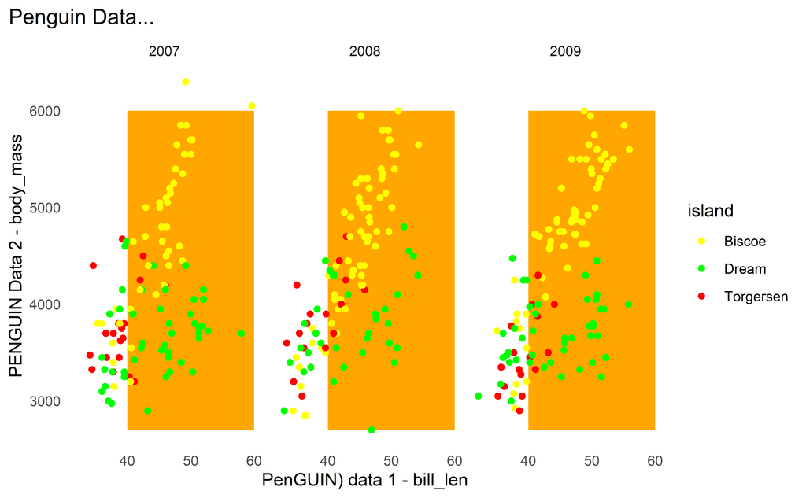

```r
ggplot(penguins, aes(x = bill_len, y = body_mass, color = island)) +
  scale_color_manual(values = c("yellow", "green", "red")) +
  geom_rect(
    xmin = 40, xmax = 60,
    ymin = 2700, ymax = 6000,
    fill = "orange", alpha = 0.3,
    inherit.aes = FALSE
  ) +
  geom_rect(
    xmin = 40, xmax = 60,
    ymin = 2700, ymax = 6000,
    fill = "orange", alpha = 0.3,
    inherit.aes = FALSE
  ) +
  geom_point() +
  facet_grid(. ~ year) +
  theme(
    plot.title.position = "plot",
    panel.grid.minor = element_blank(),
    panel.grid.major = element_blank()
  ) +
  labs(title = "Penguin Data...",
       x = "PenGUIN) data 1 - bill_len",
       y = "PENGUIN Data 2 - body_mass")
```